# Problema1

## d Impacto del tamaño muestral:

### Genera muestras aleatorias con tamaños: 5, 10, 20, 30, 40, 50, 60, 70, 80, 90, 100, 200, 300, 400, 500, 600, 700, 800, 900 y 1,000. Agrega valores si consideras que mejora el análisis de los resultados.

### Calcula la frecuencia relativa de X=3 para cada tamaño.

```
## Tamaño muestral 5 : Frecuencia relativa = 0
## Tamaño muestral 10 : Frecuencia relativa = 0.2
## Tamaño muestral 20 : Frecuencia relativa = 0.2
## Tamaño muestral 30 : Frecuencia relativa = 0.2
## Tamaño muestral 40 : Frecuencia relativa = 0.125
## Tamaño muestral 50 : Frecuencia relativa = 0.12
## Tamaño muestral 60 : Frecuencia relativa = 0.1
## Tamaño muestral 70 : Frecuencia relativa = 0.1857143
## Tamaño muestral 80 : Frecuencia relativa = 0.1125
## Tamaño muestral 90 : Frecuencia relativa = 0.1
## Tamaño muestral 100 : Frecuencia relativa = 0.15
## Tamaño muestral 200 : Frecuencia relativa = 0.13
## Tamaño muestral 300 : Frecuencia relativa = 0.1233333
## Tamaño muestral 400 : Frecuencia relativa = 0.1575
## Tamaño muestral 500 : Frecuencia relativa = 0.142
## Tamaño muestral 600 : Frecuencia relativa = 0.12
## Tamaño muestral 700 : Frecuencia relativa = 0.1485714
## Tamaño muestral 800 : Frecuencia relativa = 0.1325
## Tamaño muestral 900 : Frecuencia relativa = 0.1222222
## Tamaño muestral 1000 : Frecuencia relativa = 0.133
## Tamaño muestral 2000 : Frecuencia relativa = 0.1625
## Tamaño muestral 3000 : Frecuencia relativa = 0.1323333
## Tamaño muestral 4000 : Frecuencia relativa = 0.1395
## Tamaño muestral 5000 : Frecuencia relativa = 0.1392
## Tamaño muestral 6000 : Frecuencia relativa = 0.1356667
## Tamaño muestral 7000 : Frecuencia relativa = 0.1391429
## Tamaño muestral 8000 : Frecuencia relativa = 0.1355
## Tamaño muestral 9000 : Frecuencia relativa = 0.1377778
## Tamaño muestral 10000 : Frecuencia relativa = 0.1428
```

### Construye un gráfico de dispersión:

- Eje X: Indexación (1 al 20) por cada tamaño muestral.
- Eje Y: Frecuencias relativas fn(X=3).
- Dibuja la línea en P(X=3) y describe si aparece una tendencia.

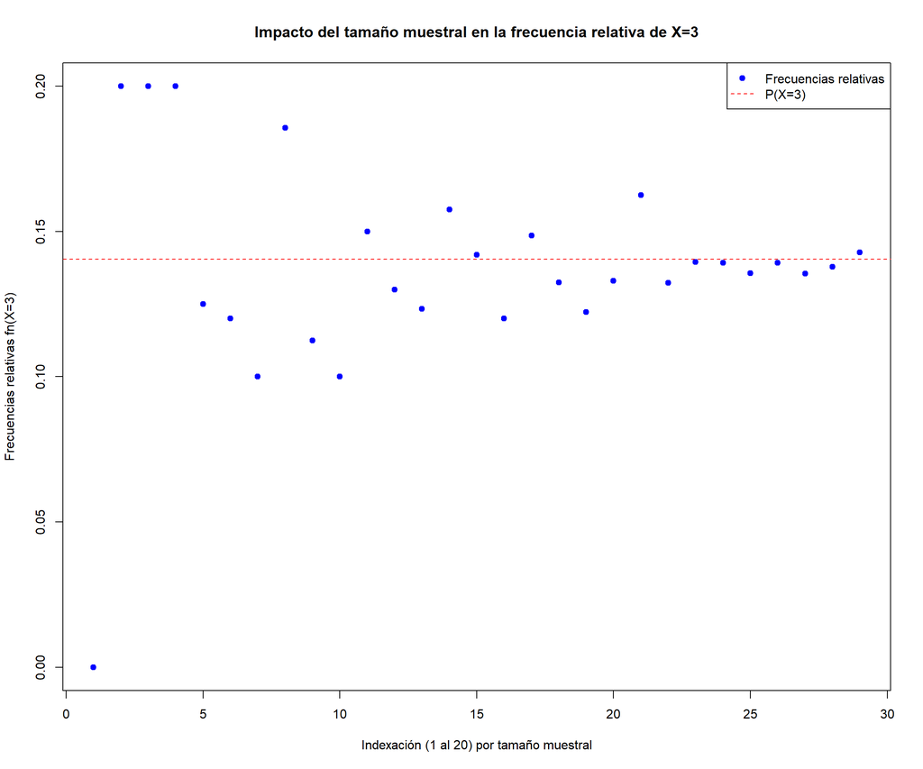

## c.Convergencia de la media muestral: - Genera 100 muestras de tamaño n=1,000.

- Calcula el promedio muestral de solicitudes en cada muestra.

```
## Media teórica λ = 5
```

```
## Muestra 1 : Promedio muestral = 4.905
## Muestra 2 : Promedio muestral = 5.176
## Muestra 3 : Promedio muestral = 5.148
## Muestra 4 : Promedio muestral = 5.08
## Muestra 5 : Promedio muestral = 5.02
## Muestra 6 : Promedio muestral = 4.991
## Muestra 7 : Promedio muestral = 4.982
## Muestra 8 : Promedio muestral = 5.059
## Muestra 9 : Promedio muestral = 4.971
## Muestra 10 : Promedio muestral = 4.915
## Muestra 11 : Promedio muestral = 5.113
## Muestra 12 : Promedio muestral = 5.143
## Muestra 13 : Promedio muestral = 4.896
## Muestra 14 : Promedio muestral = 5.033
## Muestra 15 : Promedio muestral = 5.14
## Muestra 16 : Promedio muestral = 4.924
## Muestra 17 : Promedio muestral = 4.955
## Muestra 18 : Promedio muestral = 4.876
## Muestra 19 : Promedio muestral = 4.915
## Muestra 20 : Promedio muestral = 4.917
## Muestra 21 : Promedio muestral = 5.035
## Muestra 22 : Promedio muestral = 4.838
## Muestra 23 : Promedio muestral = 4.907
## Muestra 24 : Promedio muestral = 4.957
## Muestra 25 : Promedio muestral = 5.142
## Muestra 26 : Promedio muestral = 5.003
## Muestra 27 : Promedio muestral = 4.999
## Muestra 28 : Promedio muestral = 5.02
## Muestra 29 : Promedio muestral = 5.006
## Muestra 30 : Promedio muestral = 4.9
## Muestra 31 : Promedio muestral = 4.975
## Muestra 32 : Promedio muestral = 4.857
## Muestra 33 : Promedio muestral = 4.946
## Muestra 34 : Promedio muestral = 4.925
## Muestra 35 : Promedio muestral = 4.936
## Muestra 36 : Promedio muestral = 4.981
## Muestra 37 : Promedio muestral = 4.946
## Muestra 38 : Promedio muestral = 5.065
## Muestra 39 : Promedio muestral = 4.966
## Muestra 40 : Promedio muestral = 5.06
```

[output cut: 45 more lines]

```
## Muestra 86 : Promedio muestral = 5.039
## Muestra 87 : Promedio muestral = 4.981
## Muestra 88 : Promedio muestral = 5.105
## Muestra 89 : Promedio muestral = 5.116
## Muestra 90 : Promedio muestral = 5.022
## Muestra 91 : Promedio muestral = 4.953
## Muestra 92 : Promedio muestral = 4.973
## Muestra 93 : Promedio muestral = 5.058
## Muestra 94 : Promedio muestral = 5.063
## Muestra 95 : Promedio muestral = 4.995
## Muestra 96 : Promedio muestral = 4.987
## Muestra 97 : Promedio muestral = 4.924
## Muestra 98 : Promedio muestral = 4.97
## Muestra 99 : Promedio muestral = 4.874
## Muestra 100 : Promedio muestral = 5.078
```

### Construye un gráfico de dispersión:

- Eje X: Indexación por cada muestra (1 a 100).
- Eje Y: Promedios muestrales.
- Traza la línea horizontal en la media teórica (λ ) y analiza la tendencia.

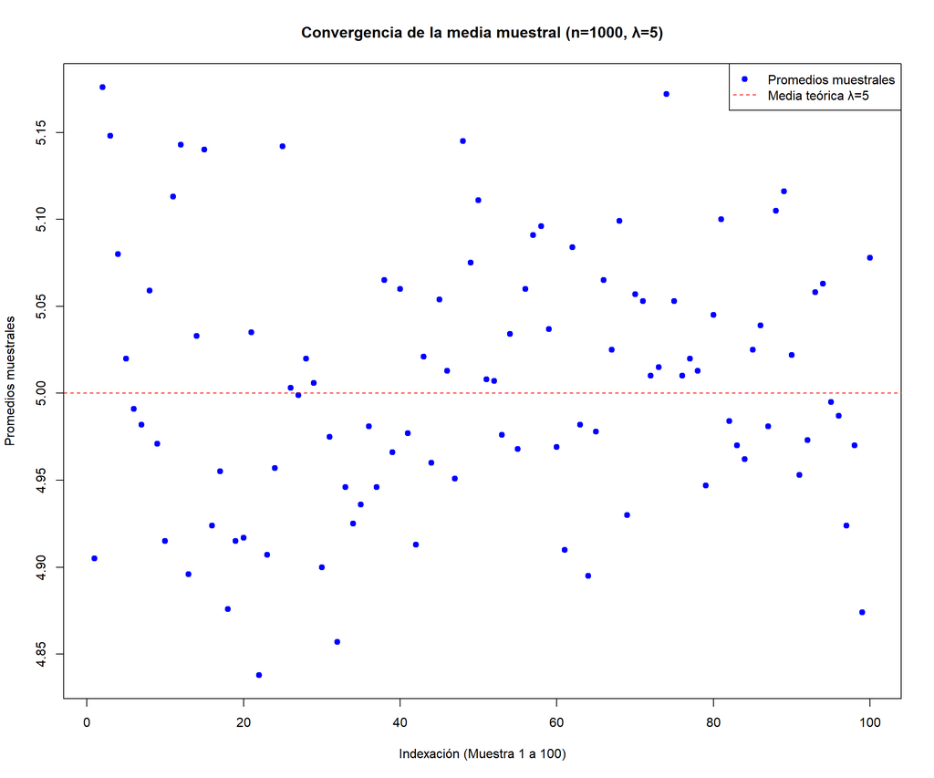

## f Impacto del tamaño muestral en la media:

- Genera muestras aleatorias con tamaños: 5, 10, 20, 30, 40, 50, 60, 70, 80, 90, 100, 200, 300, 400, 500, 600, 700, 800, 900 y 1,000. Agrega valores si consideras que mejora el análisis de los resultados.
- Calcula el promedio muestral para cada tamaño.

```
## Tamaño muestral 5 : Promedio muestral = 5.8
## Tamaño muestral 10 : Promedio muestral = 4.6
## Tamaño muestral 20 : Promedio muestral = 4.75
## Tamaño muestral 30 : Promedio muestral = 5.533333
## Tamaño muestral 40 : Promedio muestral = 5.4
## Tamaño muestral 50 : Promedio muestral = 4.4
## Tamaño muestral 60 : Promedio muestral = 4.866667
## Tamaño muestral 70 : Promedio muestral = 5.228571
## Tamaño muestral 80 : Promedio muestral = 4.6
## Tamaño muestral 90 : Promedio muestral = 5.188889
## Tamaño muestral 100 : Promedio muestral = 4.76
## Tamaño muestral 200 : Promedio muestral = 4.925
## Tamaño muestral 300 : Promedio muestral = 4.853333
## Tamaño muestral 400 : Promedio muestral = 4.9875
## Tamaño muestral 500 : Promedio muestral = 5.252
## Tamaño muestral 600 : Promedio muestral = 4.955
## Tamaño muestral 700 : Promedio muestral = 4.815714
## Tamaño muestral 800 : Promedio muestral = 4.9925
## Tamaño muestral 900 : Promedio muestral = 4.92
## Tamaño muestral 1000 : Promedio muestral = 5.016
## Tamaño muestral 2000 : Promedio muestral = 4.9675
## Tamaño muestral 3000 : Promedio muestral = 5.052333
## Tamaño muestral 4000 : Promedio muestral = 5.0075
## Tamaño muestral 5000 : Promedio muestral = 4.973
## Tamaño muestral 6000 : Promedio muestral = 4.994167
## Tamaño muestral 7000 : Promedio muestral = 5.001143
## Tamaño muestral 8000 : Promedio muestral = 4.969
## Tamaño muestral 9000 : Promedio muestral = 4.994889
## Tamaño muestral 10000 : Promedio muestral = 5.0156
```

```
##
## Media teórica λ = 5
```

### Construye un gráfico de dispersión:

- Eje X: Indexación (1 al 20) por cada tamaño muestral.
- Eje Y: Promedios muestrales.
- Dibuja la línea horizontal en la media teórica (λ) y compara si el promedio se aproxima a medida que crece el tamaño.

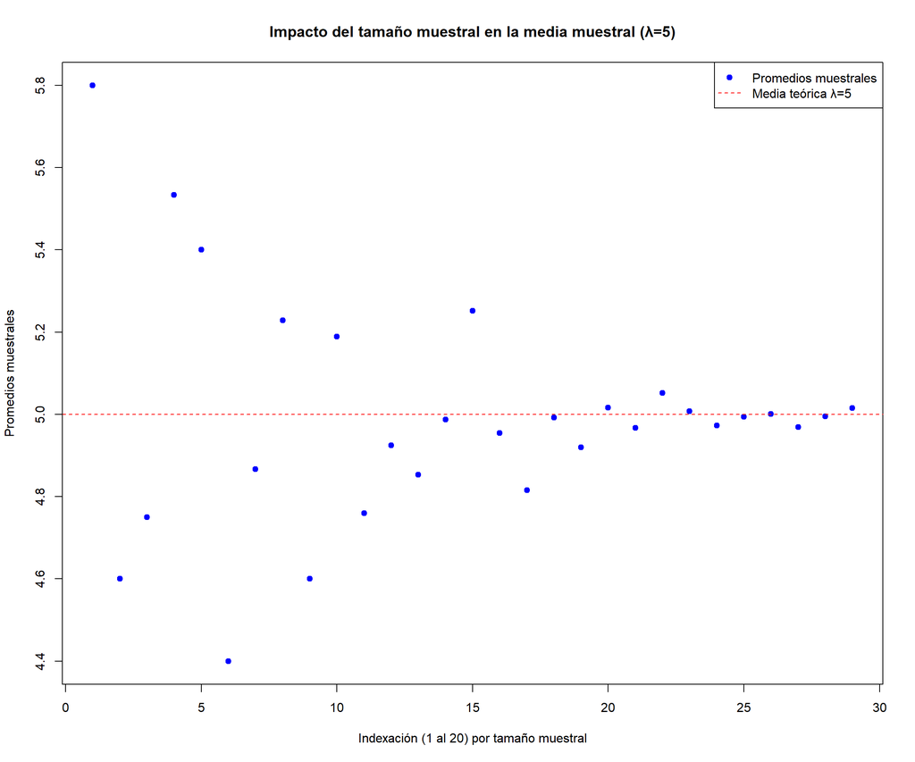